# Risk Factor Analysis

## Outcome Variable

**Outcome Variable:** wast_rec90d

## Predictor Variables

**Intervention Variable:** fage

**Adjustment Set:**

unadjusted

## Stratifying Variables

The analysis was stratified on these variable(s):

- agecat
- studyid
- country

## Data Summary

| agecat | studyid | country | fage | wast_rec90d | n_cell | n | outcome_variable |
| --- | --- | --- | --- | --- | --- | --- | --- |
| 0-24 months | ki0047075b-MAL-ED | BANGLADESH | >=38 | 0 | 12 | 77 | wast_rec90d |
| 0-24 months | ki0047075b-MAL-ED | BANGLADESH | >=38 | 1 | 22 | 77 | wast_rec90d |
| 0-24 months | ki0047075b-MAL-ED | BANGLADESH | <32 | 0 | 5 | 77 | wast_rec90d |
| 0-24 months | ki0047075b-MAL-ED | BANGLADESH | <32 | 1 | 17 | 77 | wast_rec90d |
| 0-24 months | ki0047075b-MAL-ED | BANGLADESH | [32-38) | 0 | 11 | 77 | wast_rec90d |
| 0-24 months | ki0047075b-MAL-ED | BANGLADESH | [32-38) | 1 | 10 | 77 | wast_rec90d |
| 0-24 months | ki0047075b-MAL-ED | BRAZIL | >=38 | 0 | 0 | 7 | wast_rec90d |
| 0-24 months | ki0047075b-MAL-ED | BRAZIL | >=38 | 1 | 0 | 7 | wast_rec90d |
| 0-24 months | ki0047075b-MAL-ED | BRAZIL | <32 | 0 | 0 | 7 | wast_rec90d |
| 0-24 months | ki0047075b-MAL-ED | BRAZIL | <32 | 1 | 3 | 7 | wast_rec90d |
| 0-24 months | ki0047075b-MAL-ED | BRAZIL | [32-38) | 0 | 2 | 7 | wast_rec90d |
| 0-24 months | ki0047075b-MAL-ED | BRAZIL | [32-38) | 1 | 2 | 7 | wast_rec90d |
| 0-24 months | ki0047075b-MAL-ED | INDIA | >=38 | 0 | 6 | 123 | wast_rec90d |
| 0-24 months | ki0047075b-MAL-ED | INDIA | >=38 | 1 | 9 | 123 | wast_rec90d |
| 0-24 months | ki0047075b-MAL-ED | INDIA | <32 | 0 | 23 | 123 | wast_rec90d |
| 0-24 months | ki0047075b-MAL-ED | INDIA | <32 | 1 | 28 | 123 | wast_rec90d |
| 0-24 months | ki0047075b-MAL-ED | INDIA | [32-38) | 0 | 17 | 123 | wast_rec90d |
| 0-24 months | ki0047075b-MAL-ED | INDIA | [32-38) | 1 | 40 | 123 | wast_rec90d |
| 0-24 months | ki0047075b-MAL-ED | NEPAL | >=38 | 0 | 1 | 32 | wast_rec90d |
| 0-24 months | ki0047075b-MAL-ED | NEPAL | >=38 | 1 | 5 | 32 | wast_rec90d |
| 0-24 months | ki0047075b-MAL-ED | NEPAL | <32 | 0 | 2 | 32 | wast_rec90d |
| 0-24 months | ki0047075b-MAL-ED | NEPAL | <32 | 1 | 7 | 32 | wast_rec90d |
| 0-24 months | ki0047075b-MAL-ED | NEPAL | [32-38) | 0 | 1 | 32 | wast_rec90d |
| 0-24 months | ki0047075b-MAL-ED | NEPAL | [32-38) | 1 | 16 | 32 | wast_rec90d |
| 0-24 months | ki0047075b-MAL-ED | PERU | >=38 | 0 | 0 | 10 | wast_rec90d |
| 0-24 months | ki0047075b-MAL-ED | PERU | >=38 | 1 | 1 | 10 | wast_rec90d |
| 0-24 months | ki0047075b-MAL-ED | PERU | <32 | 0 | 1 | 10 | wast_rec90d |
| 0-24 months | ki0047075b-MAL-ED | PERU | <32 | 1 | 4 | 10 | wast_rec90d |
| 0-24 months | ki0047075b-MAL-ED | PERU | [32-38) | 0 | 1 | 10 | wast_rec90d |
| 0-24 months | ki0047075b-MAL-ED | PERU | [32-38) | 1 | 3 | 10 | wast_rec90d |

[output cut: 204 more lines]

The following strata were considered:

- agecat: 0-24 months, studyid: ki0047075b-MAL-ED, country: BANGLADESH
- agecat: 0-24 months, studyid: ki0047075b-MAL-ED, country: BRAZIL
- agecat: 0-24 months, studyid: ki0047075b-MAL-ED, country: INDIA
- agecat: 0-24 months, studyid: ki0047075b-MAL-ED, country: NEPAL
- agecat: 0-24 months, studyid: ki0047075b-MAL-ED, country: PERU
- agecat: 0-24 months, studyid: ki0047075b-MAL-ED, country: SOUTH AFRICA
- agecat: 0-24 months, studyid: ki0047075b-MAL-ED, country: TANZANIA, UNITED REPUBLIC OF
- agecat: 0-24 months, studyid: ki1000304b-SAS-CompFeed, country: INDIA
- agecat: 0-24 months, studyid: ki1000304b-SAS-FoodSuppl, country: INDIA
- agecat: 0-24 months, studyid: ki1119695-PROBIT, country: BELARUS
- agecat: 0-24 months, studyid: ki1135781-COHORTS, country: GUATEMALA
- agecat: 0-24 months, studyid: ki1135781-COHORTS, country: PHILIPPINES
- agecat: 0-24 months, studyid: ki1148112-LCNI-5, country: MALAWI
- agecat: 0-6 months, studyid: ki0047075b-MAL-ED, country: BANGLADESH
- agecat: 0-6 months, studyid: ki0047075b-MAL-ED, country: BRAZIL
- agecat: 0-6 months, studyid: ki0047075b-MAL-ED, country: INDIA
- agecat: 0-6 months, studyid: ki0047075b-MAL-ED, country: NEPAL
- agecat: 0-6 months, studyid: ki0047075b-MAL-ED, country: PERU
- agecat: 0-6 months, studyid: ki0047075b-MAL-ED, country: SOUTH AFRICA
- agecat: 0-6 months, studyid: ki0047075b-MAL-ED, country: TANZANIA, UNITED REPUBLIC OF
- agecat: 0-6 months, studyid: ki1000304b-SAS-CompFeed, country: INDIA
- agecat: 0-6 months, studyid: ki1000304b-SAS-FoodSuppl, country: INDIA
- agecat: 0-6 months, studyid: ki1119695-PROBIT, country: BELARUS
- agecat: 0-6 months, studyid: ki1135781-COHORTS, country: GUATEMALA
- agecat: 0-6 months, studyid: ki1135781-COHORTS, country: PHILIPPINES
- agecat: 0-6 months, studyid: ki1148112-LCNI-5, country: MALAWI
- agecat: 6-24 months, studyid: ki0047075b-MAL-ED, country: BANGLADESH
- agecat: 6-24 months, studyid: ki0047075b-MAL-ED, country: BRAZIL
- agecat: 6-24 months, studyid: ki0047075b-MAL-ED, country: INDIA
- agecat: 6-24 months, studyid: ki0047075b-MAL-ED, country: NEPAL
- agecat: 6-24 months, studyid: ki0047075b-MAL-ED, country: PERU
- agecat: 6-24 months, studyid: ki0047075b-MAL-ED, country: SOUTH AFRICA
- agecat: 6-24 months, studyid: ki0047075b-MAL-ED, country: TANZANIA, UNITED REPUBLIC OF
- agecat: 6-24 months, studyid: ki1000304b-SAS-CompFeed, country: INDIA
- agecat: 6-24 months, studyid: ki1000304b-SAS-FoodSuppl, country: INDIA
- agecat: 6-24 months, studyid: ki1119695-PROBIT, country: BELARUS
- agecat: 6-24 months, studyid: ki1135781-COHORTS, country: GUATEMALA
- agecat: 6-24 months, studyid: ki1135781-COHORTS, country: PHILIPPINES
- agecat: 6-24 months, studyid: ki1148112-LCNI-5, country: MALAWI

### Dropped Strata

Some strata were dropped due to rare outcomes:

- agecat: 0-24 months, studyid: ki0047075b-MAL-ED, country: BRAZIL
- agecat: 0-24 months, studyid: ki0047075b-MAL-ED, country: NEPAL
- agecat: 0-24 months, studyid: ki0047075b-MAL-ED, country: PERU
- agecat: 0-24 months, studyid: ki0047075b-MAL-ED, country: SOUTH AFRICA
- agecat: 0-24 months, studyid: ki0047075b-MAL-ED, country: TANZANIA, UNITED REPUBLIC OF
- agecat: 0-24 months, studyid: ki1000304b-SAS-FoodSuppl, country: INDIA
- agecat: 0-24 months, studyid: ki1148112-LCNI-5, country: MALAWI
- agecat: 0-6 months, studyid: ki0047075b-MAL-ED, country: BANGLADESH
- agecat: 0-6 months, studyid: ki0047075b-MAL-ED, country: BRAZIL
- agecat: 0-6 months, studyid: ki0047075b-MAL-ED, country: INDIA
- agecat: 0-6 months, studyid: ki0047075b-MAL-ED, country: NEPAL
- agecat: 0-6 months, studyid: ki0047075b-MAL-ED, country: PERU
- agecat: 0-6 months, studyid: ki0047075b-MAL-ED, country: SOUTH AFRICA
- agecat: 0-6 months, studyid: ki0047075b-MAL-ED, country: TANZANIA, UNITED REPUBLIC OF
- agecat: 0-6 months, studyid: ki1000304b-SAS-FoodSuppl, country: INDIA
- agecat: 0-6 months, studyid: ki1148112-LCNI-5, country: MALAWI
- agecat: 6-24 months, studyid: ki0047075b-MAL-ED, country: BANGLADESH
- agecat: 6-24 months, studyid: ki0047075b-MAL-ED, country: BRAZIL
- agecat: 6-24 months, studyid: ki0047075b-MAL-ED, country: INDIA
- agecat: 6-24 months, studyid: ki0047075b-MAL-ED, country: NEPAL
- agecat: 6-24 months, studyid: ki0047075b-MAL-ED, country: PERU
- agecat: 6-24 months, studyid: ki0047075b-MAL-ED, country: SOUTH AFRICA
- agecat: 6-24 months, studyid: ki0047075b-MAL-ED, country: TANZANIA, UNITED REPUBLIC OF
- agecat: 6-24 months, studyid: ki1000304b-SAS-FoodSuppl, country: INDIA
- agecat: 6-24 months, studyid: ki1119695-PROBIT, country: BELARUS
- agecat: 6-24 months, studyid: ki1135781-COHORTS, country: GUATEMALA
- agecat: 6-24 months, studyid: ki1148112-LCNI-5, country: MALAWI

## Methods Detail

We’re interested in the causal parameters $E[Y_a]$ for all values of $a \in \mathcal{A}$. These parameters represent the mean outcome if, possibly contrary to fact, we intervened to set all units to have $A=a$. Under the randomization and positivity assumptions, these are identified by the statistical parameters $\psi_a=E_W[E_{Y|A,W}(Y|A=a,W)]$. In addition, we’re interested in the mean of $Y$, $E[Y]$ under no intervention (the observed mean). We will estimate these parameters by using SuperLearner to fit the relevant likelihood factors – $E_{Y|A,W}(Y|A=a,W)$ and $p(A=a|W)$, and then updating our likelihood fit using a joint TMLE.

For unadjusted analyses ($W=\{\}$), initial likelihoods were estimated using Lrnr_glm to estimate the simple $E(Y|A)$ and Lrnr_mean to estimate $p(A)$. For adjusted analyses, a small library containing Lrnr_glmnet, Lrnr_xgboost, and Lrnr_mean was used.

Having estimated these parameters, we will then use the delta method to estimate relative risks and attributable risks relative to a prespecified baseline level of $A$.

# Results Detail

## Results Plots

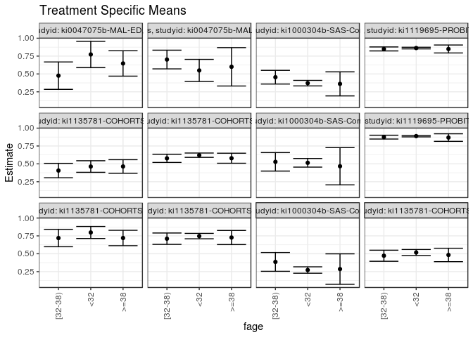

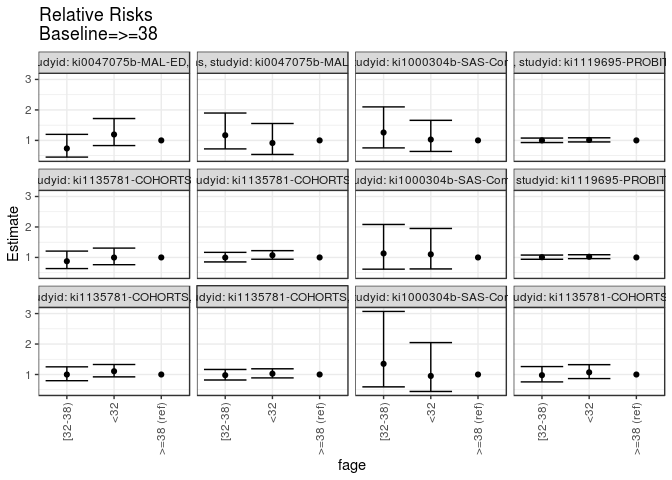

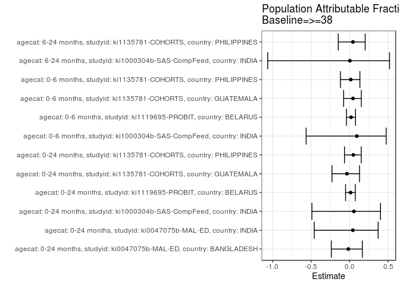

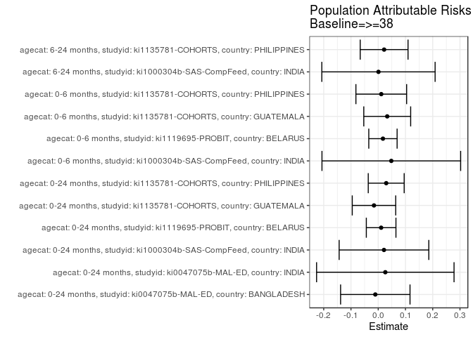

## Results Table

### Parameter: TSM

| agecat | studyid | country | intervention_level | baseline_level | estimate | ci_lower | ci_upper |
| --- | --- | --- | --- | --- | --- | --- | --- |
| 0-24 months | ki0047075b-MAL-ED | BANGLADESH | >=38 | NA | 0.6470588 | 0.4696719 | 0.8244457 |
| 0-24 months | ki0047075b-MAL-ED | BANGLADESH | <32 | NA | 0.7727273 | 0.5883808 | 0.9570738 |
| 0-24 months | ki0047075b-MAL-ED | BANGLADESH | [32-38) | NA | 0.4761905 | 0.2843868 | 0.6679942 |
| 0-24 months | ki0047075b-MAL-ED | INDIA | >=38 | NA | 0.6000000 | 0.3314652 | 0.8685348 |
| 0-24 months | ki0047075b-MAL-ED | INDIA | <32 | NA | 0.5490196 | 0.3942129 | 0.7038263 |
| 0-24 months | ki0047075b-MAL-ED | INDIA | [32-38) | NA | 0.7017544 | 0.5709473 | 0.8325615 |
| 0-24 months | ki1000304b-SAS-CompFeed | INDIA | >=38 | NA | 0.3611111 | 0.1927671 | 0.5294551 |
| 0-24 months | ki1000304b-SAS-CompFeed | INDIA | <32 | NA | 0.3714286 | 0.3327469 | 0.4101103 |
| 0-24 months | ki1000304b-SAS-CompFeed | INDIA | [32-38) | NA | 0.4545455 | 0.3586882 | 0.5504027 |
| 0-24 months | ki1119695-PROBIT | BELARUS | >=38 | NA | 0.8493976 | 0.7938288 | 0.9049664 |
| 0-24 months | ki1119695-PROBIT | BELARUS | <32 | NA | 0.8624277 | 0.8510686 | 0.8737869 |
| 0-24 months | ki1119695-PROBIT | BELARUS | [32-38) | NA | 0.8500797 | 0.8222429 | 0.8779166 |
| 0-24 months | ki1135781-COHORTS | GUATEMALA | >=38 | NA | 0.4636364 | 0.3687770 | 0.5584957 |
| 0-24 months | ki1135781-COHORTS | GUATEMALA | <32 | NA | 0.4625000 | 0.3812953 | 0.5437047 |
| 0-24 months | ki1135781-COHORTS | GUATEMALA | [32-38) | NA | 0.4062500 | 0.3055426 | 0.5069574 |
| 0-24 months | ki1135781-COHORTS | PHILIPPINES | >=38 | NA | 0.5786802 | 0.5085776 | 0.6487828 |
| 0-24 months | ki1135781-COHORTS | PHILIPPINES | <32 | NA | 0.6210247 | 0.5908047 | 0.6512448 |
| 0-24 months | ki1135781-COHORTS | PHILIPPINES | [32-38) | NA | 0.5773196 | 0.5199854 | 0.6346537 |
| 0-6 months | ki1000304b-SAS-CompFeed | INDIA | >=38 | NA | 0.4666667 | 0.2061538 | 0.7271796 |
| 0-6 months | ki1000304b-SAS-CompFeed | INDIA | <32 | NA | 0.5147059 | 0.4543062 | 0.5751055 |
| 0-6 months | ki1000304b-SAS-CompFeed | INDIA | [32-38) | NA | 0.5283019 | 0.3989989 | 0.6576049 |
| 0-6 months | ki1119695-PROBIT | BELARUS | >=38 | NA | 0.8679245 | 0.8147833 | 0.9210657 |
| 0-6 months | ki1119695-PROBIT | BELARUS | <32 | NA | 0.8881539 | 0.8773665 | 0.8989414 |
| 0-6 months | ki1119695-PROBIT | BELARUS | [32-38) | NA | 0.8739635 | 0.8472013 | 0.9007257 |
| 0-6 months | ki1135781-COHORTS | GUATEMALA | >=38 | NA | 0.7205882 | 0.6131598 | 0.8280167 |
| 0-6 months | ki1135781-COHORTS | GUATEMALA | <32 | NA | 0.7977528 | 0.7136930 | 0.8818126 |
| 0-6 months | ki1135781-COHORTS | GUATEMALA | [32-38) | NA | 0.7200000 | 0.5980967 | 0.8419033 |
| 0-6 months | ki1135781-COHORTS | PHILIPPINES | >=38 | NA | 0.7272727 | 0.6287266 | 0.8258189 |
| 0-6 months | ki1135781-COHORTS | PHILIPPINES | <32 | NA | 0.7470588 | 0.7093834 | 0.7847342 |
| 0-6 months | ki1135781-COHORTS | PHILIPPINES | [32-38) | NA | 0.7109375 | 0.6314136 | 0.7904614 |
| 6-24 months | ki1000304b-SAS-CompFeed | INDIA | >=38 | NA | 0.2857143 | 0.0723858 | 0.4990428 |
| 6-24 months | ki1000304b-SAS-CompFeed | INDIA | <32 | NA | 0.2722646 | 0.2273817 | 0.3171476 |
| 6-24 months | ki1000304b-SAS-CompFeed | INDIA | [32-38) | NA | 0.3859649 | 0.2542449 | 0.5176849 |
| 6-24 months | ki1135781-COHORTS | PHILIPPINES | >=38 | NA | 0.4833333 | 0.3891595 | 0.5775072 |
| 6-24 months | ki1135781-COHORTS | PHILIPPINES | <32 | NA | 0.5176849 | 0.4756795 | 0.5596903 |
| 6-24 months | ki1135781-COHORTS | PHILIPPINES | [32-38) | NA | 0.4723926 | 0.3949587 | 0.5498266 |

### Parameter: E(Y)

| agecat | studyid | country | intervention_level | baseline_level | estimate | ci_lower | ci_upper |
| --- | --- | --- | --- | --- | --- | --- | --- |
| 0-24 months | ki0047075b-MAL-ED | BANGLADESH | NA | NA | 0.6363636 | 0.5243346 | 0.7483927 |
| 0-24 months | ki0047075b-MAL-ED | INDIA | NA | NA | 0.6260163 | 0.5320687 | 0.7199638 |
| 0-24 months | ki1000304b-SAS-CompFeed | INDIA | NA | NA | 0.3822441 | 0.3470990 | 0.4173892 |
| 0-24 months | ki1119695-PROBIT | BELARUS | NA | NA | 0.8600988 | 0.8497563 | 0.8704412 |
| 0-24 months | ki1135781-COHORTS | GUATEMALA | NA | NA | 0.4480874 | 0.3954108 | 0.5007641 |
| 0-24 months | ki1135781-COHORTS | PHILIPPINES | NA | NA | 0.6080247 | 0.5830213 | 0.6330281 |
| 0-6 months | ki1000304b-SAS-CompFeed | INDIA | NA | NA | 0.5147059 | 0.4610948 | 0.5683169 |
| 0-6 months | ki1119695-PROBIT | BELARUS | NA | NA | 0.8852740 | 0.8754291 | 0.8951189 |
| 0-6 months | ki1135781-COHORTS | GUATEMALA | NA | NA | 0.7536232 | 0.6949302 | 0.8123162 |
| 0-6 months | ki1135781-COHORTS | PHILIPPINES | NA | NA | 0.7384615 | 0.7062339 | 0.7706892 |
| 6-24 months | ki1000304b-SAS-CompFeed | INDIA | NA | NA | 0.2866242 | 0.2446853 | 0.3285631 |
| 6-24 months | ki1135781-COHORTS | PHILIPPINES | NA | NA | 0.5049724 | 0.4705318 | 0.5394130 |

### Parameter: RR

| agecat | studyid | country | intervention_level | baseline_level | estimate | ci_lower | ci_upper |
| --- | --- | --- | --- | --- | --- | --- | --- |
| 0-24 months | ki0047075b-MAL-ED | BANGLADESH | >=38 | >=38 | 1.0000000 | 1.0000000 | 1.000000 |
| 0-24 months | ki0047075b-MAL-ED | BANGLADESH | <32 | >=38 | 1.1942149 | 0.8303676 | 1.717491 |
| 0-24 months | ki0047075b-MAL-ED | BANGLADESH | [32-38) | >=38 | 0.7359307 | 0.4521186 | 1.197903 |
| 0-24 months | ki0047075b-MAL-ED | INDIA | >=38 | >=38 | 1.0000000 | 1.0000000 | 1.000000 |
| 0-24 months | ki0047075b-MAL-ED | INDIA | <32 | >=38 | 0.9150327 | 0.5384477 | 1.554997 |
| 0-24 months | ki0047075b-MAL-ED | INDIA | [32-38) | >=38 | 1.1695906 | 0.7206230 | 1.898277 |
| 0-24 months | ki1000304b-SAS-CompFeed | INDIA | >=38 | >=38 | 1.0000000 | 1.0000000 | 1.000000 |
| 0-24 months | ki1000304b-SAS-CompFeed | INDIA | <32 | >=38 | 1.0285714 | 0.6379637 | 1.658338 |
| 0-24 months | ki1000304b-SAS-CompFeed | INDIA | [32-38) | >=38 | 1.2587413 | 0.7546320 | 2.099606 |
| 0-24 months | ki1119695-PROBIT | BELARUS | >=38 | >=38 | 1.0000000 | 1.0000000 | 1.000000 |
| 0-24 months | ki1119695-PROBIT | BELARUS | <32 | >=38 | 1.0153405 | 0.9497942 | 1.085410 |
| 0-24 months | ki1119695-PROBIT | BELARUS | [32-38) | >=38 | 1.0008031 | 0.9301994 | 1.076766 |
| 0-24 months | ki1135781-COHORTS | GUATEMALA | >=38 | >=38 | 1.0000000 | 1.0000000 | 1.000000 |
| 0-24 months | ki1135781-COHORTS | GUATEMALA | <32 | >=38 | 0.9975490 | 0.7617595 | 1.306323 |
| 0-24 months | ki1135781-COHORTS | GUATEMALA | [32-38) | >=38 | 0.8762255 | 0.6352953 | 1.208526 |
| 0-24 months | ki1135781-COHORTS | PHILIPPINES | >=38 | >=38 | 1.0000000 | 1.0000000 | 1.000000 |
| 0-24 months | ki1135781-COHORTS | PHILIPPINES | <32 | >=38 | 1.0731743 | 0.9418273 | 1.222839 |
| 0-24 months | ki1135781-COHORTS | PHILIPPINES | [32-38) | >=38 | 0.9976488 | 0.8529894 | 1.166841 |
| 0-6 months | ki1000304b-SAS-CompFeed | INDIA | >=38 | >=38 | 1.0000000 | 1.0000000 | 1.000000 |
| 0-6 months | ki1000304b-SAS-CompFeed | INDIA | <32 | >=38 | 1.1029412 | 0.6234654 | 1.951158 |
| 0-6 months | ki1000304b-SAS-CompFeed | INDIA | [32-38) | >=38 | 1.1320755 | 0.6153979 | 2.082547 |
| 0-6 months | ki1119695-PROBIT | BELARUS | >=38 | >=38 | 1.0000000 | 1.0000000 | 1.000000 |
| 0-6 months | ki1119695-PROBIT | BELARUS | <32 | >=38 | 1.0233078 | 0.9613846 | 1.089219 |
| 0-6 months | ki1119695-PROBIT | BELARUS | [32-38) | >=38 | 1.0069580 | 0.9403299 | 1.078307 |
| 0-6 months | ki1135781-COHORTS | GUATEMALA | >=38 | >=38 | 1.0000000 | 1.0000000 | 1.000000 |
| 0-6 months | ki1135781-COHORTS | GUATEMALA | <32 | >=38 | 1.1070855 | 0.9223488 | 1.328823 |
| 0-6 months | ki1135781-COHORTS | GUATEMALA | [32-38) | >=38 | 0.9991837 | 0.7973916 | 1.252042 |
| 0-6 months | ki1135781-COHORTS | PHILIPPINES | >=38 | >=38 | 1.0000000 | 1.0000000 | 1.000000 |
| 0-6 months | ki1135781-COHORTS | PHILIPPINES | <32 | >=38 | 1.0272059 | 0.8889263 | 1.186996 |
| 0-6 months | ki1135781-COHORTS | PHILIPPINES | [32-38) | >=38 | 0.9775391 | 0.8200225 | 1.165313 |
| 6-24 months | ki1000304b-SAS-CompFeed | INDIA | >=38 | >=38 | 1.0000000 | 1.0000000 | 1.000000 |
| 6-24 months | ki1000304b-SAS-CompFeed | INDIA | <32 | >=38 | 0.9529262 | 0.4435900 | 2.047089 |
| 6-24 months | ki1000304b-SAS-CompFeed | INDIA | [32-38) | >=38 | 1.3508772 | 0.5944071 | 3.070066 |
| 6-24 months | ki1135781-COHORTS | PHILIPPINES | >=38 | >=38 | 1.0000000 | 1.0000000 | 1.000000 |
| 6-24 months | ki1135781-COHORTS | PHILIPPINES | <32 | >=38 | 1.0710722 | 0.8672718 | 1.322764 |
| 6-24 months | ki1135781-COHORTS | PHILIPPINES | [32-38) | >=38 | 0.9773641 | 0.7576601 | 1.260777 |

### Parameter: PAR

| agecat | studyid | country | intervention_level | baseline_level | estimate | ci_lower | ci_upper |
| --- | --- | --- | --- | --- | --- | --- | --- |
| 0-24 months | ki0047075b-MAL-ED | BANGLADESH | >=38 | NA | -0.0106952 | -0.1380673 | 0.1166770 |
| 0-24 months | ki0047075b-MAL-ED | INDIA | >=38 | NA | 0.0260163 | -0.2262080 | 0.2782405 |
| 0-24 months | ki1000304b-SAS-CompFeed | INDIA | >=38 | NA | 0.0211330 | -0.1433720 | 0.1856381 |
| 0-24 months | ki1119695-PROBIT | BELARUS | >=38 | NA | 0.0107012 | -0.0436471 | 0.0650495 |
| 0-24 months | ki1135781-COHORTS | GUATEMALA | >=38 | NA | -0.0155489 | -0.0953032 | 0.0642054 |
| 0-24 months | ki1135781-COHORTS | PHILIPPINES | >=38 | NA | 0.0293445 | -0.0365766 | 0.0952656 |
| 0-6 months | ki1000304b-SAS-CompFeed | INDIA | >=38 | NA | 0.0480392 | -0.2064266 | 0.3025050 |
| 0-6 months | ki1119695-PROBIT | BELARUS | >=38 | NA | 0.0173494 | -0.0346235 | 0.0693223 |
| 0-6 months | ki1135781-COHORTS | GUATEMALA | >=38 | NA | 0.0330350 | -0.0530076 | 0.1190775 |
| 0-6 months | ki1135781-COHORTS | PHILIPPINES | >=38 | NA | 0.0111888 | -0.0818684 | 0.1042461 |
| 6-24 months | ki1000304b-SAS-CompFeed | INDIA | >=38 | NA | 0.0009099 | -0.2069616 | 0.2087814 |
| 6-24 months | ki1135781-COHORTS | PHILIPPINES | >=38 | NA | 0.0216390 | -0.0661150 | 0.1093931 |

### Parameter: PAF

| agecat | studyid | country | intervention_level | baseline_level | estimate | ci_lower | ci_upper |
| --- | --- | --- | --- | --- | --- | --- | --- |
| 0-24 months | ki0047075b-MAL-ED | BANGLADESH | >=38 | NA | -0.0168067 | -0.2377087 | 0.1646694 |
| 0-24 months | ki0047075b-MAL-ED | INDIA | >=38 | NA | 0.0415584 | -0.4592634 | 0.3704973 |
| 0-24 months | ki1000304b-SAS-CompFeed | INDIA | >=38 | NA | 0.0552867 | -0.4899315 | 0.4009905 |
| 0-24 months | ki1119695-PROBIT | BELARUS | >=38 | NA | 0.0124418 | -0.0528161 | 0.0736547 |
| 0-24 months | ki1135781-COHORTS | GUATEMALA | >=38 | NA | -0.0347007 | -0.2290491 | 0.1289156 |
| 0-24 months | ki1135781-COHORTS | PHILIPPINES | >=38 | NA | 0.0482620 | -0.0665554 | 0.1507190 |
| 0-6 months | ki1000304b-SAS-CompFeed | INDIA | >=38 | NA | 0.0933333 | -0.5644012 | 0.4745309 |
| 0-6 months | ki1119695-PROBIT | BELARUS | >=38 | NA | 0.0195978 | -0.0409101 | 0.0765885 |
| 0-6 months | ki1135781-COHORTS | GUATEMALA | >=38 | NA | 0.0438348 | -0.0777541 | 0.1517065 |
| 0-6 months | ki1135781-COHORTS | PHILIPPINES | >=38 | NA | 0.0151515 | -0.1192843 | 0.1334404 |
| 6-24 months | ki1000304b-SAS-CompFeed | INDIA | >=38 | NA | 0.0031746 | -1.0634622 | 0.5184497 |
| 6-24 months | ki1135781-COHORTS | PHILIPPINES | >=38 | NA | 0.0428519 | -0.1477224 | 0.2017822 |